# Covid 19

## Background and Data

Although by this point some of you may be avoiding the information overload surrounding Covid-19, understanding what is currently happening by getting up-to-date data directly from the source, and extracting one’s own conclusions can be empowering.

At this point of the term you’ve already an R toolbox broad enough to tackle the massive amount of data found in Johns Hopkins COVID-19 repository [(click here)](https://github.com/CSSEGISandData/COVID-19/tree/master/csse_covid_19_data). These data has been updated daily since the COVID-19 pandemic started. I also included links to other supplementary data sets to **potentially** explore the effectiveness of measures taken throughout the pandemic, including-mask use and vaccination. The datasets included are:

1. **covid.ts.cases**: daily time series for the confirmed number of COVID-19 cases at the county level for the US (file description [here](https://github.com/CSSEGISandData/COVID-19/blob/master/csse_covid_19_data/csse_covid_19_time_series/README.md)).
2. **covid.ts.deaths**: daily time series for the confirmed number of COVID-19 deaths at the county level for the US (file description [here](https://github.com/CSSEGISandData/COVID-19/blob/master/csse_covid_19_data/csse_covid_19_time_series/README.md)).
3. **covid.usa.daily**: COVID-19 USA daily state reports with the number of confirmed cases between April 14th and May 7th (file description [here](https://github.com/CSSEGISandData/COVID-19/tree/master/csse_covid_19_data#daily-reports-csse_covid_19_daily_reports)).
4. **Vaccination data**: state level COVID-19 daily vaccination numbers time series data from the Johns Hopkins University repository (file description [here](https://github.com/govex/COVID-19/blob/master/data_tables/vaccine_data/us_data/readme.md), )
5. **Mask use data**: information on mask use in the NY Times repository (file description [here](https://github.com/nytimes/covid-19-data/tree/master/mask-use#readme)).
6. **State policy data**: data files (one file by state) about dates and description of policies going into/out of effect. To load data for a particular state go to [this link](https://github.com/govex/COVID-19/tree/govex_data/data_tables/policy_data/table_data/Current), find the name of the state file you want to work with.

Here is the data:

```r
# confirmed COVID-19 time series cases US (trimmed to include from 11/01/2020 to 05/12/2021)
covid.usa.ts.confirmed <- read_csv('https://raw.githubusercontent.com/CSSEGISandData/COVID-19/master/csse_covid_19_data/csse_covid_19_time_series/time_series_covid19_confirmed_US.csv') %>% select(c(1:11,296:488))

# Confirmed COVID-19 time series deaths US (trimmed to include from 11/01/2020 to 05/12/2021)
covid.usa.ts.deaths <- read_csv('https://raw.githubusercontent.com/CSSEGISandData/COVID-19/master/csse_covid_19_data/csse_covid_19_time_series/time_series_covid19_deaths_US.csv') %>% select(c(1:11,296:488))

# Daily data summary by state for 05-12-2021
covid.usa.daily <- read_csv("https://raw.githubusercontent.com/CSSEGISandData/COVID-19/master/csse_covid_19_data/csse_covid_19_daily_reports_us/05-12-2021.csv")

# US vaccinated people data
vacc.people <- read_csv("https://raw.githubusercontent.com/govex/COVID-19/master/data_tables/vaccine_data/us_data/time_series/people_vaccinated_us_timeline.csv")

# mask use data
maskuse <- read_csv("https://raw.githubusercontent.com/nytimes/covid-19-data/master/mask-use/mask-use-by-county.csv")

# Texas
policytrackerTX <- read_csv("https://raw.githubusercontent.com/govex/COVID-19/govex_data/data_tables/policy_data/table_data/Current/Texas_policy.csv")

# Florida
policytrackerFL <- read_csv("https://raw.githubusercontent.com/govex/COVID-19/govex_data/data_tables/policy_data/table_data/Current/Florida_policy.csv")

# Hawaii
policytrackerHI <- read_csv("https://raw.githubusercontent.com/govex/COVID-19/govex_data/data_tables/policy_data/table_data/Current/Hawaii_policy.csv")

# Maine
policytrackerME <- read_csv("https://raw.githubusercontent.com/govex/COVID-19/govex_data/data_tables/policy_data/table_data/Current/Maine_policy.csv")

# Montana
policytrackerMT <- read_csv("https://raw.githubusercontent.com/govex/COVID-19/govex_data/data_tables/policy_data/table_data/Current/Montana_policy.csv")

# California
policytrackerCA <- read_csv("https://raw.githubusercontent.com/govex/COVID-19/govex_data/data_tables/policy_data/table_data/Current/California_policy.csv")
```

## Part 1: Wrangling the COVID-19 time series data

1. Using the time series data sets `covid.usa.ts.confirmed` and `covid.use.ts.deaths`, which are both at the county level and are in wide format, reshape them into long format (using either of the functions `gather` or `pivot_longer`) to generate a single new data frame with the daily time series **BY STATE** including both number of confirmed cases and deaths, so that you have one row for each combination of state and date. Call this new data frame `covid.usa.states.ts`. **Note**: after reshaping your file into long format, your new `date` column (or however you decide to call it) needs to be converted into a `Date-Time` type variable. For example, if your variable is called `my.date.variable`, you can make this conversion using `lubridate::mdy(my.date.variable)`.

```
## # A tibble: 5 x 4
## # Groups:   Province_State [1]
##   Dates      Deaths Province_State Confirmed_Cases
##   <date>      <dbl> <chr>                    <dbl>
## 1 2021-01-01   4872 Alabama                 365747
## 2 2021-01-10   5334 Alabama                 401900
## 3 2021-01-11   5347 Alabama                 404000
## 4 2021-01-12   5573 Alabama                 407848
## 5 2021-01-13   5760 Alabama                 410995
```

2. Append to `covid.usa.states.ts` (created in previous problem) all of the information from matching rows in `vacc.people` (without repeating columns with the same info in the two data sets).

```
## # A tibble: 5 x 6
## # Groups:   Province_State [1]
##   Dates      Province_State Deaths Confirmed_Cases People_Fully_Vaccinated
##   <date>     <chr>           <dbl>           <dbl>                   <dbl>
## 1 2021-01-01 Alabama          4872          365747                      NA
## 2 2021-01-10 Alabama          5334          401900                      NA
## 3 2021-01-11 Alabama          5347          404000                      NA
## 4 2021-01-12 Alabama          5573          407848                      NA
## 5 2021-01-13 Alabama          5760          410995                      NA
## # … with 1 more variable: People_Partially_Vaccinated <dbl>
```

Note: People_Fully_Vaccinated and People_Partially_Vaccinated show as NA because of the dates displayed were before the vaccine was released.

## Part 2: Let’s use the data

1. Using `covid.usa.daily` select *3 highly impacted states*, *3 mildly impacted states* by COVID-19, where by ‘highly impacted’ I mean the states with high numbers of confirmed cases.

**Highly Impacted States**

- California (3,763,281 confirmed)
- Texas (2,922,680 confirmed)
- Florida (2,278,549 confirmed)

**Mildly Impacted States**

- Hawaii (34,917 confirmed)
- Maine (64,748 confirmed)
- Montana (110,317 confirmed)
2. Create a visualization of the evolution of confirmed cases, deaths, and people vaccinated for each of the 6 states identified as *highly* and *mildly* impacted (use the `covid.usa.states.ts` data.frame to create the figure).

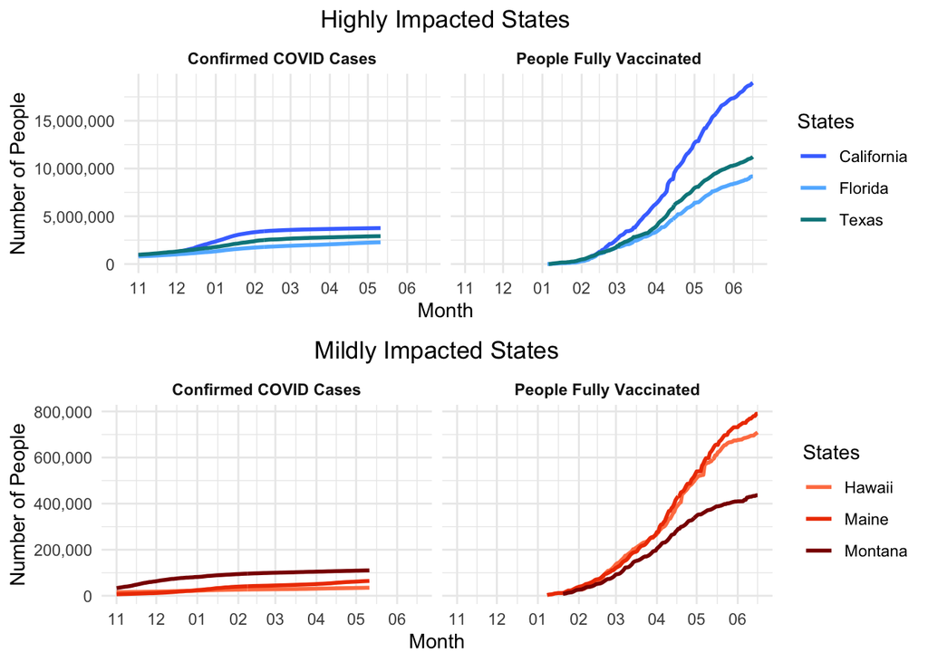

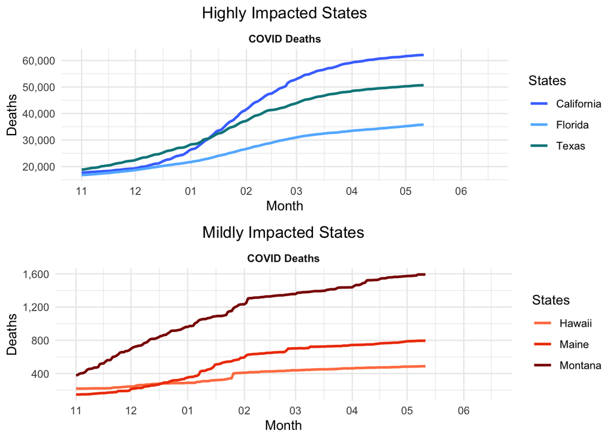

3. Do you see any interesting change in the trajectories of the corresponding time series for the number of cases and deaths taking place with vaccinations? Produce **meaningful** summaries that enable you to quantify this change (e.g., average number of new cases in windows of 90 days before vs 90 days after vaccination started). One or two summary measures is good. Make either a table or a figure to display your findings and comment on them.

Hawaii

Average Daily COVID Cases and Deaths 90 Days Before and After the Vaccine

|  | 90 Days Before Vaccine | 90 Days After Vaccine |
| --- | --- | --- |
| Average Confirmed Cases | 21,738.58 | 30,698.38 |
| Average Deaths | 297.30 | 458.05 |

Maine

Average Daily COVID Cases and Deaths 90 Days Before and After the Vaccine

|  | 90 Days Before Vaccine | 90 Days After Vaccine |
| --- | --- | --- |
| Average Confirmed Cases | 14,705.47 | 42,874.47 |
| Average Deaths | 236.53 | 647.44 |

Montana

Average Daily COVID Cases and Deaths 90 Days Before and After the Vaccine

|  | 90 Days Before Vaccine | 90 Days After Vaccine |
| --- | --- | --- |
| Average Confirmed Cases | 67,038.40 | 100,255.80 |
| Average Deaths | 769.41 | 1,370.69 |

California

Average Daily COVID Cases and Deaths 90 Days Before and After the Vaccine

|  | 90 Days Before Vaccine | 90 Days After Vaccine |
| --- | --- | --- |
| Average Confirmed Cases | 2,121,173.24 | 3,639,255.15 |
| Average Deaths | 26,717.37 | 56,556.90 |

Florida

Average Daily COVID Cases and Deaths 90 Days Before and After the Vaccine

|  | 90 Days Before Vaccine | 90 Days After Vaccine |
| --- | --- | --- |
| Average Confirmed Cases | 1,049,231.80 | 1,818,799.32 |
| Average Deaths | 19,097.03 | 28,963.04 |

Texas

Average Daily COVID Cases and Deaths 90 Days Before and After the Vaccine

|  | 90 Days Before Vaccine | 90 Days After Vaccine |
| --- | --- | --- |
| Average Confirmed Cases | 1,371,918.26 | 2,515,123.77 |
| Average Deaths | 23,334.68 | 41,117.35 |

4. Using information from the `maskuse` data explore if mask use seems to correlate with your selected states being midly or highly impacted.

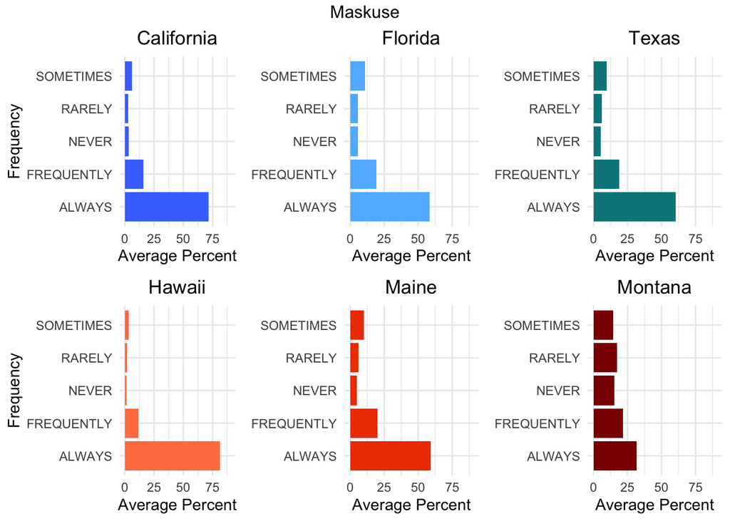

5. Formulate and explore ONE question about the 3 highly and 3 mildly affected states with any of the datasets I have provided, or by using the policy tracker datasets corresponding to your states.

**How do open and closure days relate to number of Deaths, Confirmed Cases, and People Fully Vaccinated from 3 highly affected states (California, Florida, Texas), and 3 mildly affected states (Hawaii, Maine, Montana)?**

Note:

Opening are shown with gold vertical lines

Closures are shown with red vertical lines

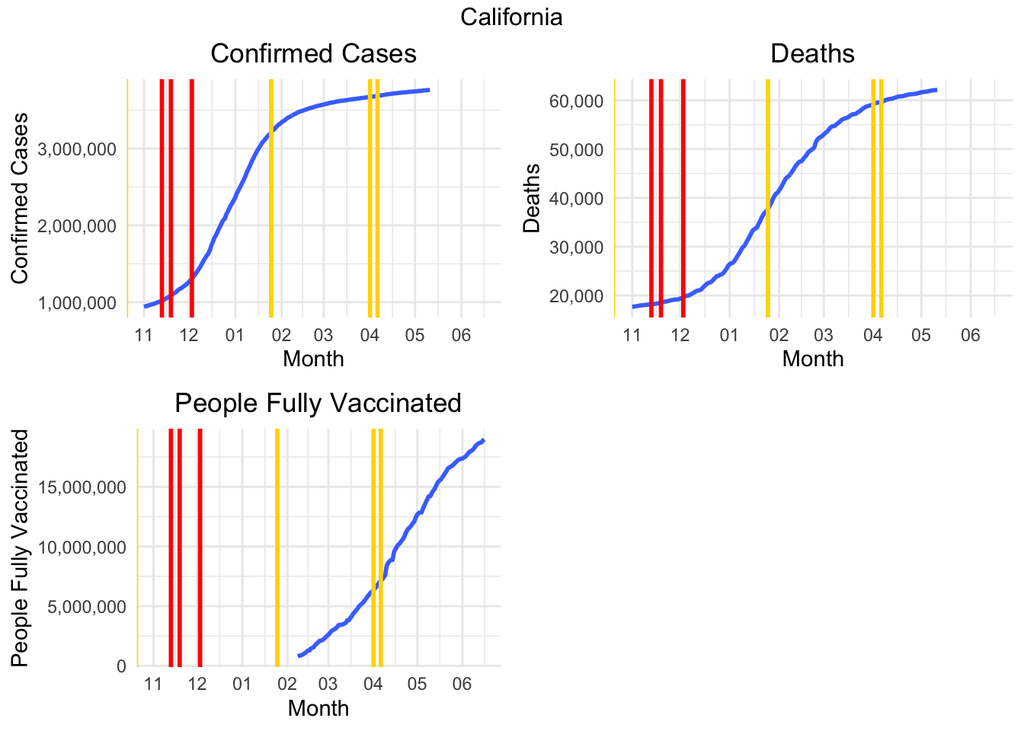

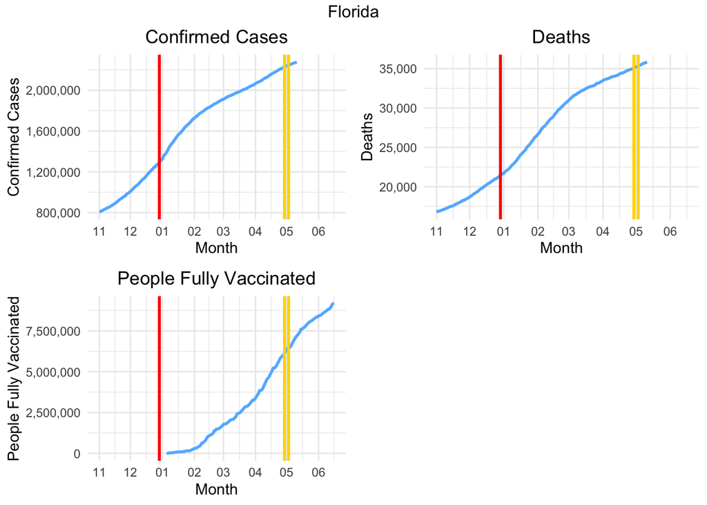

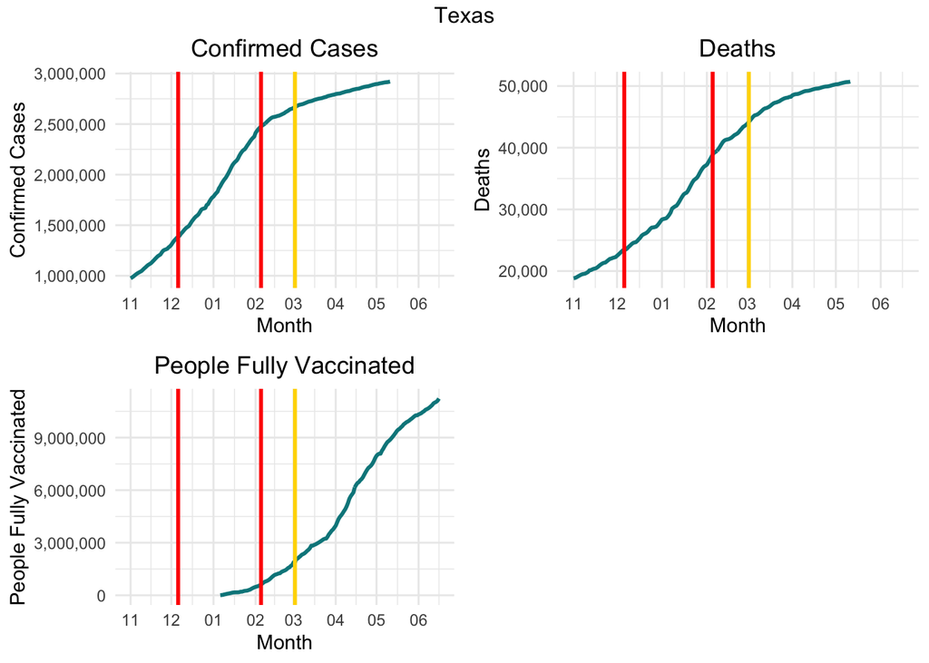

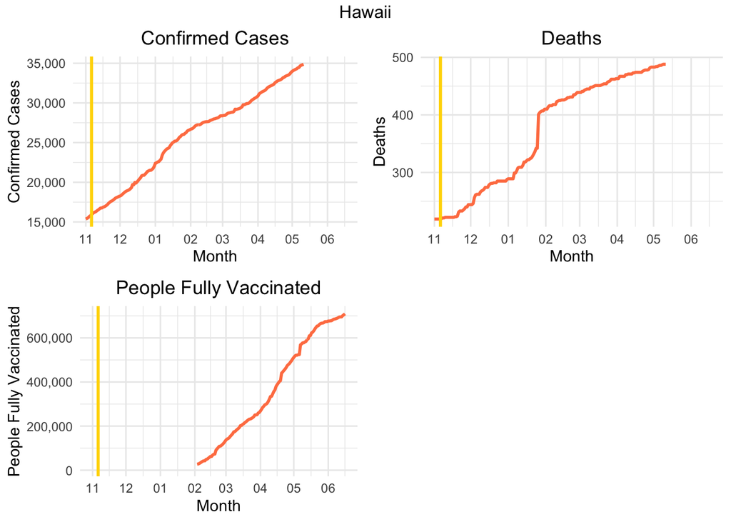

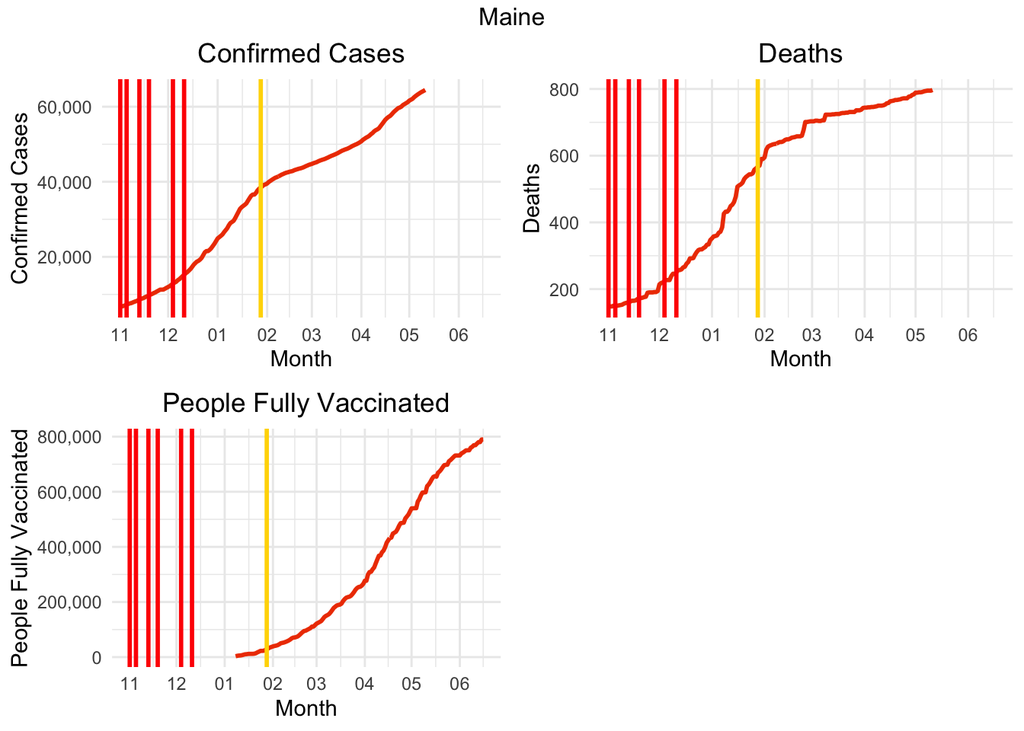

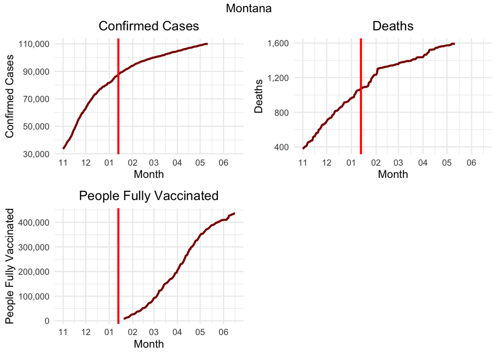